# Bayesian Inference for Binomial Proportion (Ch.8)

## V. Estimating the proportion

Any of the measures of location above can be used as a point estimator, $\hat{\pi}$, of $\pi$. One way to justify a choice of $\hat{\pi}$ is by analyzing the

PMSE = Posterior Mean Squared **Error** which is defined as

$$PMSE[\hat{\pi}] = \int_0^1 (\pi - \hat{\pi})^2 g(\pi|y)d\pi.$$

By adding and substracting the posterior mean, $m^{\prime}$ inside the squared term, we can decompose this integral into two components the **variance** and the squared **bias**.

$$PMSE[\hat{\pi}] = Var[\pi|y] + (m^{\prime} - \hat{\pi})^2.$$

Often estimators are evaluated by this so-called variance-bias tradeoff. Clearly, PMSE is minimized at $\hat{\pi} = m^{\prime}$.

## VI. Bayesian credible intervals

Of course, **a statistician is never satistified by a mere point estimator**! We have the entire distribution, but we may desire an probability interval around our point estimator. In the Bayesian universe, we call this a credible interval (analogous to a confidence interval but MUCH easier to interpret). There are multiple ways to form these intervals

1. A highest posterior density interval. The shortest interval (or union of intervals) with the desired probability
2. A percentile-based interval (equal tails).
3. Normal approximation (appropriate when $a^{\prime}, b^{\prime} \geq 10$).

Let’s look this post to https://stats.stackexchange.com/questions/148439/what-is-a-highest-density-region-hdr

### Back to Chris’s general continuous prior

```r
pi = seq(0, 1, by = 0.001)
pi.prior = rep(0, length(pi))
priorFun = Bolstad::createPrior(x = c(0, 0.1, 0.3, 0.5), wt = c(0, 2, 2, 0))
```

```
## Normalizing prior. Normalizing constant: 0.6999994
```

```r
pi.prior = priorFun(pi)
results <- Bolstad::binogcp(26, 100, "user", pi = pi, pi.prior = pi.prior)
```

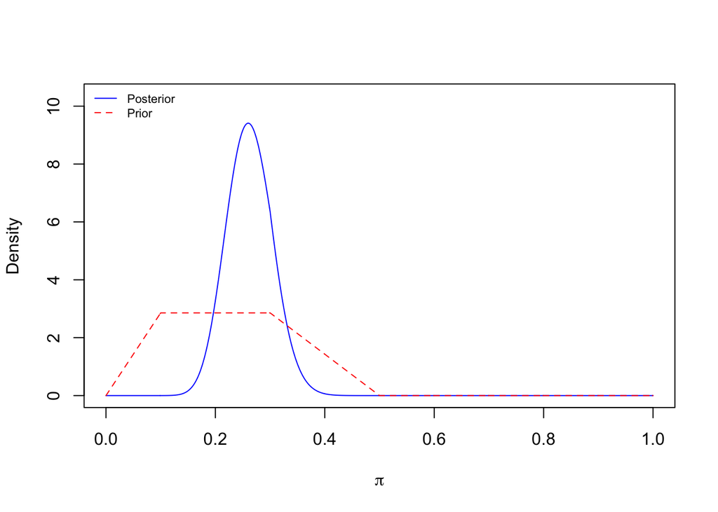

```r
alpha <- 0.05
qtls <- quantile(results, probs = c(alpha/2, 1-(alpha/2)))
cat(paste("Approximate 95% credible interval : ["
        , round(qtls[1], 4), " ", round(qtls[2], 4), "]\n", sep = ""))
```

```
## Approximate 95% credible interval : [0.1832 0.3456]
```

## Closing

- Explain in your own words what it means to summarize a posterior distribution.
- Why is this considered *conducting statistical inferences*?